# • Linear Regression Error

# And make a helper plot function to see if our functions are working correctly.

```python
def plot_points_and_lines(weights_fx, X, Y, color="blue", label="f(x)"):
    """Creates the plot of f(x) and g(x) lines along with labeled points

       Args:
        weights_fx:  tuple representing (intercept, slope) of f(x)
        weights_gx:  tuple representing (intercept, slope) of g(x)
        X: an N X D array representing the coordinates of of the points
        Y: an N X 1 array representing +1 or -1

    """

    line = np.linspace(-1, 1, 1001) # points from 0-1000

    plt.plot(line, line * weights_fx[1] + weights_fx[0], label=label, color=color) # makes f(x) line

    plt.ylim(-1, 1)
    plt.xlim(-1, 1)

    plt.scatter(X[:, 1][Y.ravel()==1],  X[:, 2][Y.ravel()== 1], marker="+", c=("r"), label="+")
    plt.scatter(X[:, 1][Y.ravel()==-1], X[:, 2][Y.ravel()==-1], marker="_", c=("b"), label="-")# colored based on Y = +1 or -1
    plt.legend(loc="best")
```

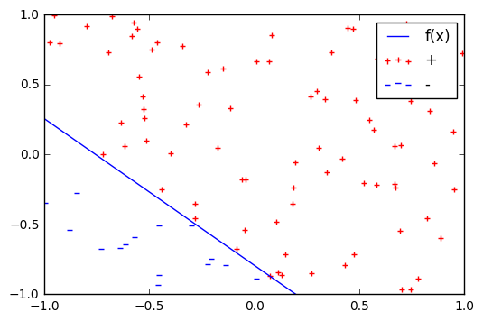

```python
w_fx = make_weights_for_fx()
X, Y, w = create_random_points_and_labels(100, w_fx)
plot_points_and_lines(w_fx, X, Y)
```

# It looks like we're good to go $😃$

# Now for our logistic regression algorithm using stochastic gradient descent!

# If you were feeling like this ¯\*(ツ)*/¯ don't worry it was difficult for me too! Luckily the discussion forums provided some insight $😃$

# Here is the summary of the steps:

# 1: Initialize the weights at $t = 0$ to $w(0)$

# 2: Create a $100$ data points and labels $(x_n, y_n)$

# 3: while $\Vert {\mathrm {\mathbf w^{(t−1)}} − \mathrm {\mathbf w^{(t)}}}\Vert > \epsilon$ do

# 3(a) Set $\mathrm {\mathbf w^{(n)}} = \mathrm {\mathbf w^{(t)}}$

# 3(b) shuffle all of the data points

# 3(b-1): for $n = 0, 1, 2, . . .$ do

# 3(c): for each data point $(x_n, y_n)$ compute

# 3(c-1): $∇e\bigl(h(x_n), y_n\bigr) = −\frac{y_nx_n}{1 + e^{y_nw^{T(n)}x_n}}$

# 3(c-2): $\mathbf w^{(n+1)} = \mathbf w^{(n)} - \eta ∇e\bigl(h(x_n), y_n\bigr) $

# 3(c-3) $\mathbf w^{(n)} = \mathbf w^{(n+1)}; \to $ reuse the $\mathbf w^{(n+1)}$ for the next data point

# 3(d): $\mathbf w^{(t+1)} = \mathbf w^{(N)}$

# 3(e): Calculate $\Vert {\mathrm {\mathbf w^{(t)}} − \mathrm {\mathbf w^{(t+1)}}}\Vert$

# 3(d): $\mathbf w^{(t)} = \mathbf w^{(t+1)}$

# end

# return $\mathrm {\mathbf w^{(t)}}$

```python
def logistic_regression_SGD(N=100):

    w_fx = make_weights_for_fx()  # make a random f(x)
    X, Y, w_fx_3d = create_random_points_and_labels(N, w_fx) # now create points and labels

    epsilon = 0.01
    eta = 0.01
    epoch = 0

    w_gx_t = np.zeros(len(w_fx_3d))  # initialize your g(x) weights to zero

    tolerance = np.inf # initialize an arbitrary hight tolerance infinity should work ;)
    tolerances = [] # to create a nice graph to look at our ||w(t-1) - w(t)|| over epochs

    while tolerance > epsilon:
        idx = np.arange(N)
        np.random.shuffle(idx) # shuffle indices

        w_gx = np.copy(w_gx_t) # w(n) = w(t)
                               # I have to make a deep copy or else
                               # I'll create a cyclic reference!

        for n in idx: # go through shuffled data points and labels
            gradient = -(Y[n] * X[n])/(1 + np.exp(Y[n] * np.dot(w_gx, X[n]))) # no need to sum and divide by N = 1
            w_gx -= eta * gradient # stochastic update per data point

        w_gx_t_1 = w_gx  # w(t+1) = w(N)

        tolerance = np.linalg.norm(w_gx_t - w_gx_t_1) # ||w(t) - w(t + 1)||
        tolerances.append(tolerance)

        w_gx_t = w_gx_t_1 # w(t) = w(t + 1)
        epoch += 1

    w_gx_3d = w_gx_t

    return (w_fx_3d, w_gx_3d, X, Y, epoch, tolerances)
```

```python
w_fx_3d, w_gx_3d, X, Y, epoch, tolerances = logistic_regression_SGD()
print("This run took approximately {} epochs.".format(epoch))
```

```
This run took approximately 340 epochs.
```

# Let's plot $\Vert {\mathrm {\mathbf w^{(t−1)}} − \mathrm {\mathbf w^{(t)}}}\Vert$ over $t$

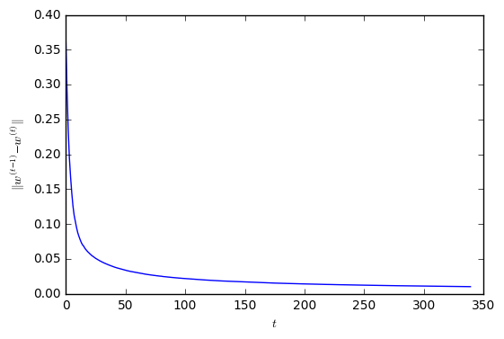

```python
plt.xlabel("$t$")
plt.ylabel("$\Vert   w^{(t−1)} −  w^{(t)}\Vert$")
plt.plot(tolerances)
```

# As you can see from the graph that the SGD approaches a minimum

# Let's look at our see how our $f(x)$ compares to the $g(x)$ we got from SGD

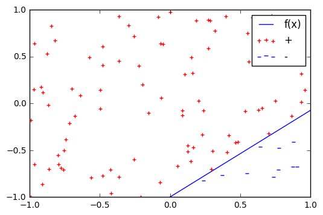

```python
plt.title
plot_points_and_lines(w_3dim_to_2dim(w_fx_3d), X, Y)
```

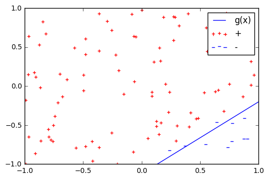

```python
plot_points_and_lines(w_3dim_to_2dim(w_gx_3d), X, Y, label="g(x)")
```

# As you can see our $g(x)$ only misclassifies only three points for this data set!

# Now that we have our SGD function let's answer the following questions

# 8. Which of the following is closest to $E_{out}$ for $N = 100$?

# [a] 0.025

# [b] 0.050

# [c] 0.075

# [d] 0.100

# [e] 0.125

# 9. How many epochs does it take on average for Logistic Regression to converge for $N = 100$ using the above initialization and termination rules and the specified learning rate? Pick the value that is closest to your results.

# [a] 350

# [b] 550

# [c] 750

# [d] 950

# [e] 1750

# Our logistic regression function already calculates these quantities. We just have to run them a $100$ times and take the average!!!

```python
runs = 100
E_outs = np.zeros(runs)
epochs = np.zeros(runs)

for run in range(runs):
    w_fx_3d, w_gx_3d, X, Y, epoch, tolerances = logistic_regression_SGD(N=100)
    E_outs[run] = np.mean(np.log(1 + np.exp(-Y * np.expand_dims(np.dot(X, w_gx_3d), 1))))
    epochs[run] = epoch

avg_E_out = np.mean(E_outs)
avg_epochs = np.mean(epochs)
```

```python
print("The average E_out over a 100 runs is {}".format(round(avg_E_out, 3)))
```

```
The average E_out over a 100 runs is 0.093
```

# The closest $E_{out}$ to $0.093$ is [d] $0.100$

```python
print("The average epochs over a 100 runs is {}".format(int(avg_epochs)))
```

```
The average epochs over a 100 runs is 347
```

# The closest average epochs to $347$ is [a] $350$

# • PLA as SGD

# 10. The Perceptron Learning Algorithm can be implemented as SGD using which of the following error functions $e_n(\mathbf w)$? Ignore the points $\mathbf w$ at which $e_n(\mathbf w)$ is not twice differentiable.

# [a] $e_n(\mathbf w) = e^{−y_n\mathbf w^T\mathbf x_n}$

# [b] $e_n(\mathbf w) = −y_n\mathbf w^T\mathbf x_n$

# [c] $e_n(\mathbf w) = (y_n - \mathbf w^T\mathbf x_n)^2$

# [d] $e_n(\mathbf w) = ln(1 + e^{−y_n\mathbf w^T\mathbf x_n} )$

# [e] $e_n(\mathbf w) = − min(0, y_n\mathbf w^T\mathbf x_n)$

# Let's look at the Stochastic Gradient Descent algorithm for Logistic regression:

# $\mathbf w^{(t+1)} = \mathbf w^{(t)} - \eta ∇e\bigl(h(x_n), y_n\bigr) $

# $\mathbf w^{(t+1)} = \mathbf w^{(t)} - \eta \bigl(−\frac{y_nx_n}{1 + e^{y_nw^{T(t)}x_n}}\bigr)$

# (1) $\mathbf w^{(t+1)} = \mathbf w^{(t)} + y_nx_n \bigl(\frac{\eta}{1 + e^{y_nw^{T(t)}x_n}}\bigr)$

# Now let's look at the Perceptron Learning Algorithm:

# (2) $\mathbf w^{(t+1)} = \mathbf w^{(t)} + y_nx_n $ for $sign(\mathbf w^T \mathbf x_n) \neq y_n$

# Hmmmmm... formulas (1) and (2) have the same form.

# Also formula two tells us that PLA can either be:

# $\mathbf w^{(t+1)} = \mathbf w^{(t)} + y_nx_n $ for $sign(\mathbf w^T \mathbf x_n) \neq y_n$

# or

# $\mathbf w^{(t+1)} = \mathbf w^{(t)} + 0 $ for $sign(\mathbf w^T \mathbf x_n) = y_n$

# This is essentially a piecewise function and the only answer that has a form of the piecewise function is $e_n(\mathbf w) = − min(0, y_n\mathbf w^T\mathbf x_n)$.

# Let's look at this further

# $\mathbf w^{(t+1)} = \mathbf w^{(t)} - \eta ∇e\bigl(h(x_n), y_n\bigr) $

# $\mathbf w^{(t+1)} = \mathbf w^{(t)} - \eta ∇e_n(\mathbf w) $

# Set $\eta = 1$

# $\mathbf w^{(t+1)} = \mathbf w^{(t)} + ∇\bigl(min(0, y_n\mathbf w^T\mathbf x_n\bigr) $

# $\mathbf w^{(t+1)} = \mathbf w^{(t)} + \ min(0, y_n\mathbf x_n) $

# $\downarrow $

# $\mathbf w^{(t+1)} = \mathbf w^{(t)} + y_nx_n $

# or

# $\mathbf w^{(t+1)} = \mathbf w^{(t)} + 0 $

# QED

# The answer is [e]